### 5월/1주

#### ▶ ▣ 정당지지도 ▣

더불어민주당 37.3%, 국민의힘 32.8%, 녹색정의당 1.6%, 새로운미래 1.8%, 개혁신당 5.4%, 조국혁신당 10.7%, 진보당 1.5%, 그 외 다른 정당 1.7%, 지지하는 정당 없다 6.6%, 잘 모르겠다 0.6%

#### ▶ ▣ 대통령 국정 수행 평가 ▣

잘하고 있다 30.4%, 잘못하고 있다 68.0%, 잘 모르겠다 1.5%

#### ☑ ▣ 차기 대권 주자 적합도 ▣

김동연 3.3%, 안철수 1.6%, 오세훈 4.5%, 원희룡 5.0%, 이재명 39.3%, 이준석 5.7%, 조국 8.1%, 한동훈 21.9%, 홍준표 4.7%, 그 외 다른 인물 1.8%, 없다 3.1%, 잘 모르겠다 1.1%

#### ☑ ▣ 차기 국무총리 적합도 ▣

권영세 15.7%, 박영선 11.2%, 이주영 2.4%, 주호영 14.5%, 그 외 다른 인물 18.9%, 없다 28.5%, 잘 모르겠다 8.7%

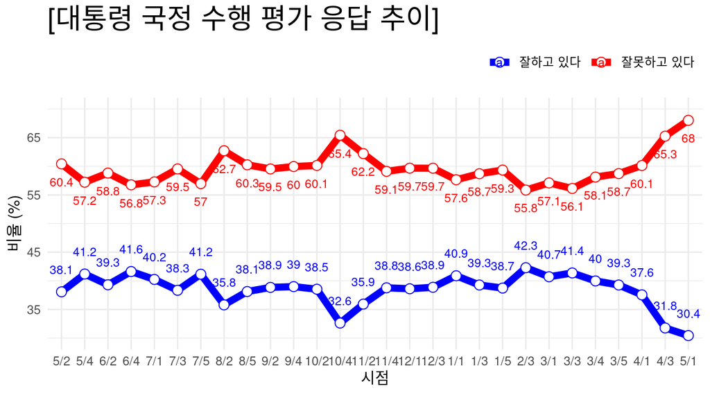

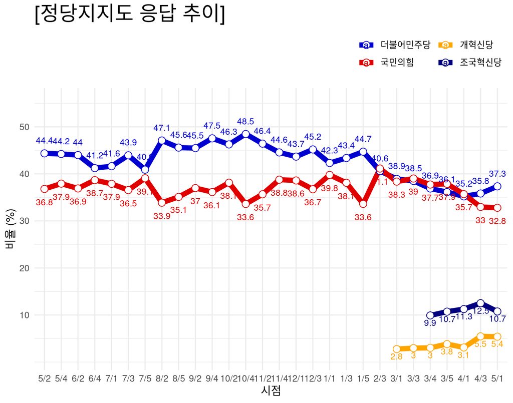

### 추가사항

- [주요질문 / 집단별 세부통계 보기](https://modernity.shinyapps.io/survey_str/) (링크누르시오)

### 참고사항

- 표본수: 2,006명,표본오차는 95% ±2.2%p
- 조사정보: 스트레이트뉴스의 의뢰로 조원씨앤아이가 2024년 4월 27일~4월 29일 3일간

  전국 만 18세 이상 남녀를 대상으로 ARS 여론조사

  (휴대전화 100% RDD 방식, 성,연령대,지역별 비례할당 후 무작위 추출)를 실시한 결과이며,

  표본수는 2,006(총 통화시도 83,190명, 응답률 2.4%)

  ※ 가중치 부여 방식: [림가중] 성별, 연령별, 지역별 가중값 부여(2024년 3월말 행정안전부 발표 주민등록인구기준)
- [중앙선거여론조사심의위원회](https://nesdc.go.kr/portal/bbs/B0000005/list.do?menuNo=200467)에서 관련사항 확인가능

2024.05.01 (Wed) 09:25 제작

- 연구개발 단계입니다.
- 제공: 감동과 마음의 [조원씨앤아이](http://jowoncni.com/html/index.html)